# Heart Rate Monitors

# Sample 2

```r
bitdata <- read.table("sample2.txt")
names(bitdata) <- c("nSeq","I1","I2","I3","I4","raw")
head(bitdata)
```

```
##   nSeq I1 I2 I3 I4 raw
## 1    0  1  1  1  1 444
## 2    1  1  1  1  1 448
## 3    2  1  1  1  1 444
## 4    3  1  1  1  1 448
## 5    4  1  1  1  1 448
## 6    5  1  1  1  1 444
```

```r
str(bitdata)
```

```
## 'data.frame':    360315 obs. of  6 variables:
##  $ nSeq: int  0 1 2 3 4 5 6 7 8 9 ...
##  $ I1  : int  1 1 1 1 1 1 1 1 1 1 ...
##  $ I2  : int  1 1 1 1 1 1 1 1 1 1 ...
##  $ I3  : int  1 1 1 1 1 1 1 1 1 1 ...
##  $ I4  : int  1 1 1 1 1 1 1 1 1 1 ...
##  $ raw : int  444 448 444 448 448 444 448 445 448 446 ...
```

# Data conversion/cleaning

The data received from the Bitalino device needs to be converted into the standard units of measurement, which in this case is Volts.I am converting the raw values obtained from bitalino into appropriate values by the formula: ECGV = (ECGB * Vcc / 2^n - Vcc / 2) / GECG

Where: ECGV - ECG value in Volts (V) ECGmV - ECG value in miliVolts (mV) ECGB - ECG value obtained from BITalino Vcc - Operating Voltage (V) n - number of bits (bit) GECG - ECG Sensor Gain

Values: Vcc = 3.3 (V) GECG = 1100 n= 10 (for Channel 3) ##Sample 1

```r
#Converting to ECG data in V
my.data$ECG <- sapply(my.data$raw,function(x)(x*3.3/2^10 - 3.3/2)/1100)
head(my.data$ECG)
```

```
## [1]  1.640625e-04 -8.496094e-05 -1.201172e-04  2.929687e-06 -1.201172e-04
## [6] -7.324219e-05
```

```r
#Write in file for Kubios software
ecgdatalist1 <- c(my.data$ECG)
write.table(ecgdatalist1,file="ecgdata1.txt")
#I manually removed the first column from this file
```

## Sample 2

```r
#Converting to ECG data in V
bitdata$ECG <- sapply(bitdata$raw,function(x)(x*3.3/2^10 - 3.3/2)/1100)
head(bitdata$ECG)
```

```
## [1] -0.0001992188 -0.0001875000 -0.0001992188 -0.0001875000 -0.0001875000
## [6] -0.0001992188
```

```r
#Write in file for Kubios software
ecgdatalist2 <- c(bitdata$ECG)
write.table(ecgdatalist2,file="ecgdata2.txt")
#I manually removed the first column from this file
```

## Convert Bitalino data to RR interval using Kubios- opening the converted files

# Sample1

```r
hrv1.kubios <- read.csv("ecghrv1.csv")
names(hrv1.kubios) <- c("Time","RR Interval","FFT Frequency","PSD","AR Frequency","PSD")
head(hrv1.kubios)
```

```
##    Time RR Interval FFT Frequency      PSD AR Frequency      PSD
## 1 1.257       0.774         0.000 137015.2        0.000 103867.3
## 2 2.047       0.791         0.004 304276.5        0.004 207235.8
## 3 2.814       0.767         0.008 379153.5        0.008 205756.2
## 4 3.541       0.726         0.012 257172.4        0.012 203343.8
## 5 4.247       0.707         0.016 352241.2        0.016 200075.0
## 6 4.924       0.676         0.020 304595.4        0.020 196047.7
```

# Sample 2

```r
hrv2.kubios <- read.csv("ecghrv2.csv")
names(hrv2.kubios) <- c("Time","RR Interval","FFT Frequency","PSD","AR Frequency","PSD")
head(hrv2.kubios)
```

```
##    Time RR Interval FFT Frequency       PSD AR Frequency      PSD
## 1 1.038       0.738         0.000 146670.29        0.000 42284.50
## 2 1.841       0.803         0.004 168941.70        0.004 83908.63
## 3 2.666       0.825         0.008  82098.87        0.008 81989.45
## 4 3.471       0.806         0.012  69517.98        0.012 78983.23
## 5 4.270       0.798         0.016  71810.11        0.016 75135.28
## 6 5.005       0.735         0.020  61683.29        0.020 70719.15
```

## Data cleaning and conversion

The RR interval data has to be converted into beats per minute. The formula for conversion is RR interval for 1 minute = 1/bpm. As the RR is in seconds I am converting it to minutes and then inversing it to get the beats per minute value.

# Sample 1

```r
#Episode one - sitting - calculate RR for 12:25
B1 <- 60/(mean(hrv1.kubios[1:85,2])) #Bitalino
F1 <- newdata$bpm[6] #time=12:25

#Episode two - walking - calculate RR for 12:30
B2 <- 60/(mean(hrv1.kubios[337:422,2]))
F2 <- newdata$bpm[7] #time=12:30

#Episode three - sitting again - calculate RR for 12:35
B3 <- 60/(mean(hrv1.kubios[653:726,2]))
F3 <- newdata$bpm[8] #time=12:35


bitalino <- c(B1, B2, B3)
fitbit <- c(F1, F2, F3)
```

# Sample 2

```r
#Calculating for every 5 minutes - thus, calculating 12 data points
a <- 60/mean((hrv2.kubios[314:394,2])) #18:15 - 240 to 300 seconds
b <- 60/mean((hrv2.kubios[716:795,2]))  #18:20 - 540 to 600 seconds
c <- 60/mean((hrv2.kubios[1091:1164,2]))  #18:25 - 840 to 900 seconds
d <- 60/mean((hrv2.kubios[1443:1521,2]))  #18:30 - 1140 to 1200 seconds
e <- 60/mean((hrv2.kubios[1813:1893,2]))  #18:35 - 1440 to 1500 seconds
f <- 60/mean((hrv2.kubios[2181:2256,2]))  #18:40 - 1740 to 1800 seconds
g <- 60/mean((hrv2.kubios[2548:2620,2]))  #18:45 - 2040 to 2100 seconds
h <- 60/mean((hrv2.kubios[2917:2989,2]))  #18:50 - 2340 to 2400 seconds
i <- 60/mean((hrv2.kubios[3280:3354,2]))  #18:55 - 2640 to 2700 seconds
j <- 60/mean((hrv2.kubios[3654:3727,2]))  #19:00 - 2940 to 3000 seconds
k <- 60/mean((hrv2.kubios[4022:4097,2]))  #19:05 - 3240 to 3300 seconds
l <- 60/mean((hrv2.kubios[4401:4476,2]))  #19:10 - 3540 to 3600 seconds

bitalino2 <- c(a,b,c,d,e,f,g,h,i,j,k,l)
fitbit2 <- c(fitdata$bpm)
```

# visualization

The data can be visualized to check overall trend - ecg RR interval data

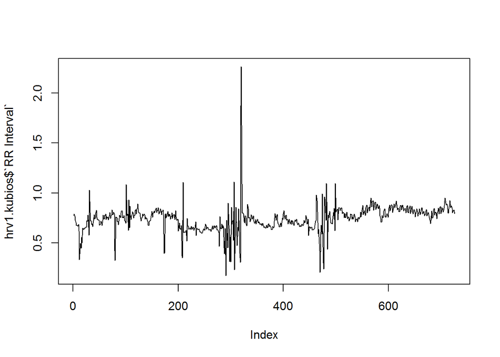

```r
plot(hrv1.kubios$`RR Interval`,type="l")
```

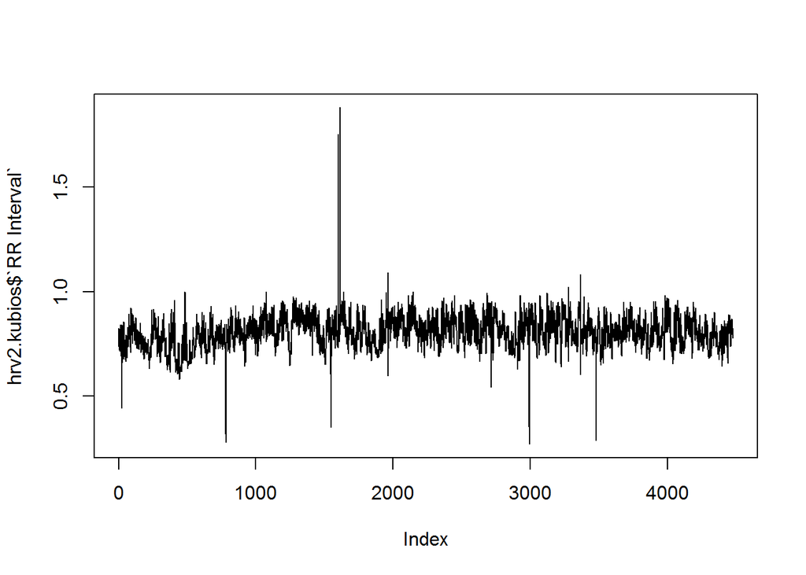

```r
plot(hrv2.kubios$`RR Interval`,type="l")
```

## Signal processing

I have used a code [3] to process the ECG data obtained from Bitalino to pass low and high pass filters so as to visualize the data. The sampling rate used was 100Hz. The purpose of this is to only visualization of the data. Sample 2 has been visualized here.

```r
#Transform the real and imaginary portions of the
#FFT into magnitude and phase.
amplitude <- function( x ) { sqrt(Re(x)^2+Im(x)^2) }
phase     <- function( x ) { atan(Im(x)/Re(x)) }

#sinc function of frequency f
sinc      <- function( x, f ) { ifelse(x==0, 2*pi*f, sin(2*pi*f*x)/x) }

#Blackman window from 0..m
Blackman  <- function( m ) { 0.42-0.5*cos(2*pi*(0:m)/m)+0.08*cos(4*pi*(0:m)/m) }

#Hamming window from 0..m
Hamming   <- function( m ) { 0.54-0.46*cos(2*pi*(0:m)/m) }

#simple low pass filter
#y - vector to filter
#t - time interval between measurements (s)
#f - low pass frequency (Hz)
lpf <- function( y, t, f ) {
  rc <- 1 / ( 2 * pi * f )
  a  <- t / ( t + rc )
  n  <- length( y )
  yf <- y
  for( i in 2:length(y) ) {
    yf[i] <- a * y[i] + (1-a) * yf[i-1]
  }
  return( yf )
}

#windowed sinc low pass filter
#y - vector to filter
#t - time interval between measurements (s)
#f - low pass frequency (Hz)
wlpf <- function( y, t, f ) {
  m  <- min(floor(length(y)/2), 500)
  #generate the sinc kernel
  rk <- sinc(-m:m, f*t)
  #apply the Blackman window
  bk <- Blackman(2*m) * rk
  #pad the filter with zeros
  k  <- c(bk, rep(0,length(y)-length(bk)))
  #convolve y with the filter kernel
  fy  <- fft(fft(k)*fft(y), inverse=TRUE)
  return(Re(fy))
}

dat  <- scan(file="ecgdata2.csv")
dat  <- (dat - mean(dat)) / sd(dat)

#filter high frequency noise
fdat <- wlpf(dat, 1/100, 30)
fdat <- (fdat-mean(fdat))/sd(fdat)

#filter low frequency noise
rdat <- wlpf(dat, 1/100, 1)
rdat <- (rdat-mean(rdat))/sd(rdat)

#use low pass filter in ecg signal
edat <- fdat - rdat

require(lattice)
```

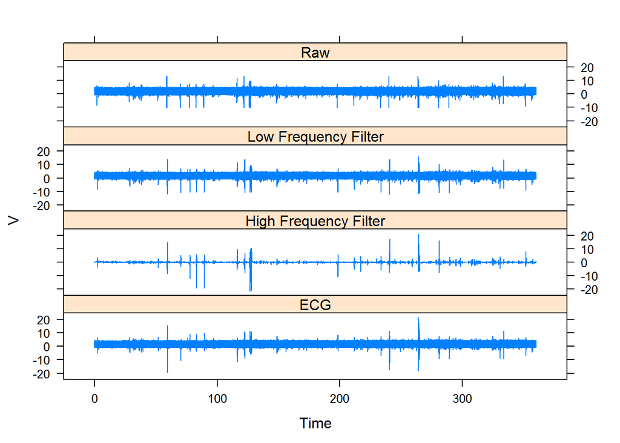

```r
xplot <- rep((0:(length(dat)-1))/1000,4)
yplot <- c(dat,fdat,rdat,edat)
gplot <- c(rep("Raw",length(dat)),
           rep("Low Frequency Filter",length(dat)),
           rep("High Frequency Filter",length(dat)),
           rep("ECG",length(dat)))

tp <- xyplot(yplot~xplot|gplot,type="l",layout=c(1,4), xlab="Time", ylab="V")

#uncomment the following to save an image
#trellis.device(png, file="ecgfilter.png", height=750, width=750)
print(tp)
```

```r
#dev.off()
```

# Results

The results of the data can be first visualized by histograms:

## Sample 1

```r
total <- data.frame(c(fitbit,bitalino))
names(total)<- c("bpm")
total$episode <- c("walking","standing","sitting")
total$device <- c("fitbit","fitbit","fitbit","bitalino","bitalino","bitalino")
total
```

```
##        bpm  episode   device
## 1 74.00000  walking   fitbit
## 2 86.00000 standing   fitbit
## 3 74.00000  sitting   fitbit
## 4 85.03401  walking bitalino
## 5 84.82935 standing bitalino
## 6 73.25766  sitting bitalino
```

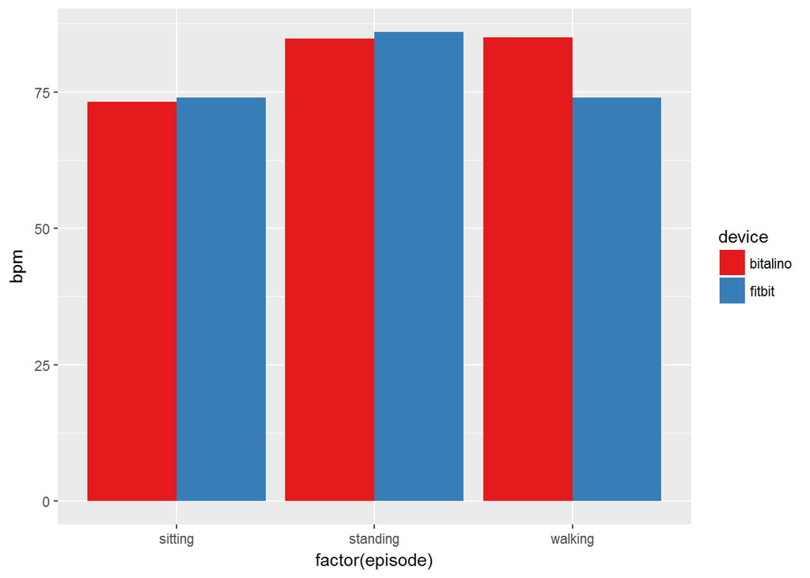

```r
ggplot(total, aes(factor(episode),bpm, fill = device)) +
  geom_bar(stat="identity", position = "dodge") +
  scale_fill_brewer(palette = "Set1")
```

## Sample 2

```r
total2 <- data.frame(c(fitbit2,bitalino2))
names(total2)<- c("bpm")
total2$time <- c("05","10","15","20","25","30","35","40","45","50","55","60")
total2$device <- c("fitbit","fitbit","fitbit","fitbit","fitbit","fitbit","fitbit","fitbit","fitbit","fitbit","fitbit","fitbit","bitalino","bitalino","bitalino","bitalino","bitalino","bitalino","bitalino","bitalino","bitalino","bitalino","bitalino","bitalino")
total2
```

```
##         bpm time   device
## 1  78.00000   05   fitbit
## 2  78.00000   10   fitbit
## 3  75.00000   15   fitbit
## 4  70.00000   20   fitbit
## 5  69.00000   25   fitbit
## 6  68.00000   30   fitbit
## 7  71.00000   35   fitbit
## 8  71.00000   40   fitbit
## 9  72.00000   45   fitbit
## 10 67.00000   50   fitbit
## 11 68.00000   55   fitbit
## 12 71.00000   60   fitbit
## 13 80.65185   05 bitalino
## 14 78.92660   10 bitalino
## 15 73.34600   15 bitalino
## 16 77.74825   20 bitalino
## 17 80.61172   25 bitalino
## 18 75.51794   30 bitalino
## 19 72.42303   35 bitalino
## 20 71.81976   40 bitalino
## 21 73.69559   45 bitalino
## 22 73.17194   50 bitalino
## 23 74.86210   55 bitalino
## 24 75.73115   60 bitalino
```

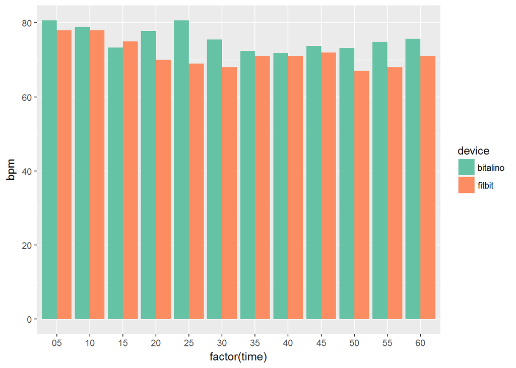

```r
ggplot(total2, aes(factor(time),bpm, fill = device)) +
  geom_bar(stat="identity", position = "dodge") +
  scale_fill_brewer(palette = "Set2")
```

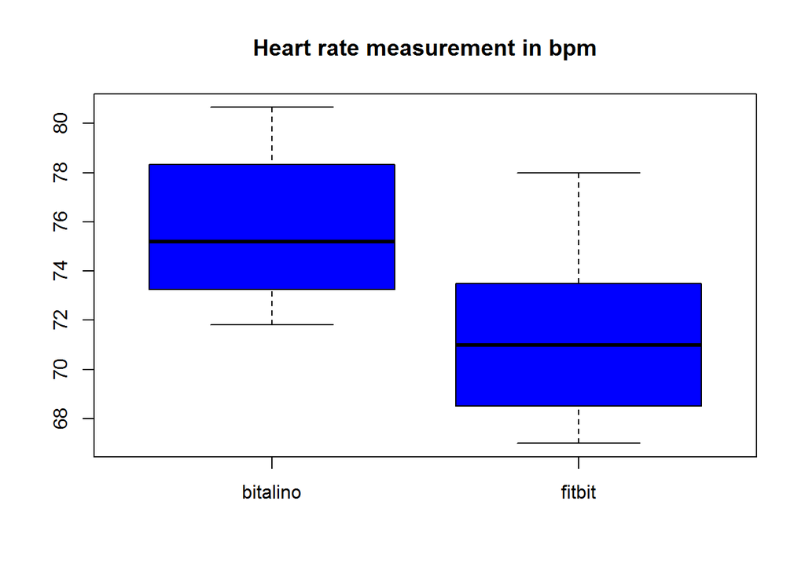

```r
#boxplots
boxplot(bpm~device, data=total2,col="blue", main="Heart rate measurement in bpm")
```

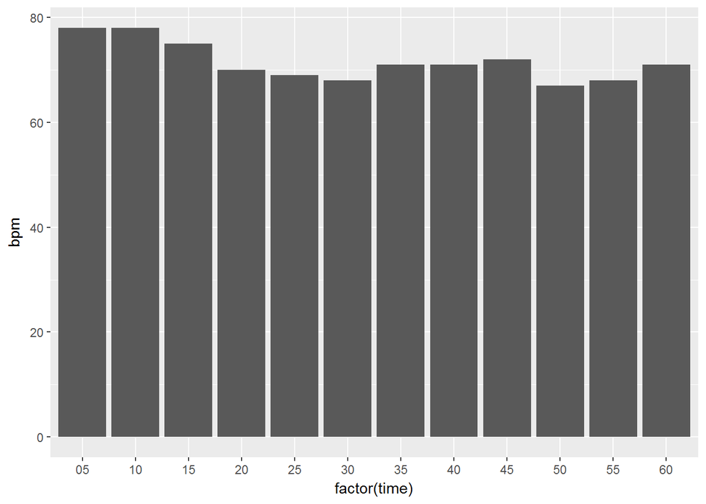

```r
#Histograms
ggplot(total2[1:12,], aes(factor(time),bpm)) +
  geom_bar(stat="identity", position = "dodge") +
  scale_fill_brewer(palette = "Set1")
```

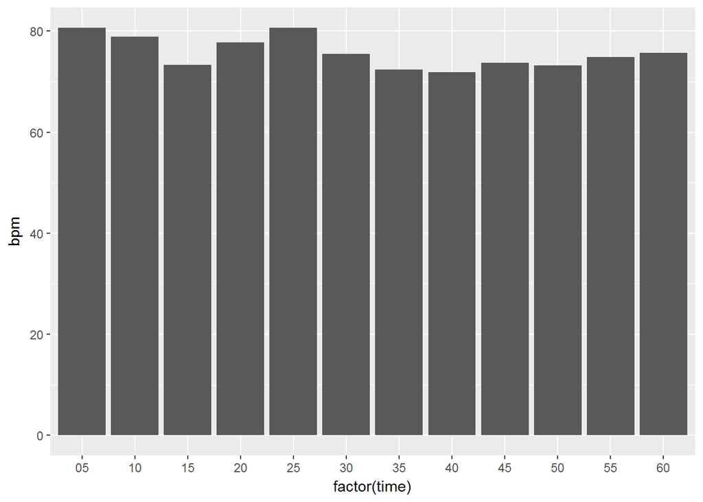

```r
ggplot(total2[12:24,], aes(factor(time),bpm)) +
  geom_bar(stat="identity", position = "dodge") +
  scale_fill_brewer(palette = "Set2")
```

## BlandAltman Plots

The converted results can be analysed by plotting BlandAltman plots to check the accuracy of the measurements.The majority of the points are within the limits of agreement (the 2 dotted lines at the end representing +1.96 SD and -1.96 SD from top to bottom. The middle dotted line is the mean difference between the two methods.)

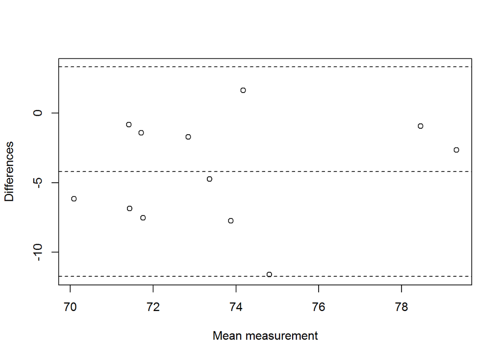

```r
bland.altman.plot(fitbit2, bitalino2, xlab = "Mean measurement", ylab= "Differences")
```

```r
bland.altman.stats(fitbit2, bitalino2)
```

```
## $means
##  [1] 79.32593 78.46330 74.17300 73.87413 74.80586 71.75897 71.71151
##  [8] 71.40988 72.84779 70.08597 71.43105 73.36558
##
## $diffs
##  [1]  -2.6518528  -0.9265983   1.6540018  -7.7482531 -11.6117202
##  [6]  -7.5179438  -1.4230299  -0.8197619  -1.6955881  -6.1719376
## [11]  -6.8620961  -4.7311544
##
## $groups
##    group1   group2
## 1      78 80.65185
## 2      78 78.92660
## 3      75 73.34600
## 4      70 77.74825
## 5      69 80.61172
## 6      68 75.51794
## 7      71 72.42303
## 8      71 71.81976
## 9      72 73.69559
## 10     67 73.17194
## 11     68 74.86210
## 12     71 75.73115
##
## $based.on
## [1] 12
##
## $lower.limit
## [1] -11.744
##
## $mean.diffs
## [1] -4.208828
##
## $upper.limit
## [1] 3.326342
##
## $lines
## lower.limit  mean.diffs upper.limit
##  -11.743998   -4.208828    3.326342
##
## $CI.lines
## lower.limit.ci.lower lower.limit.ci.upper   mean.diff.ci.lower
##          -15.9748140           -7.5131824           -6.6514905
##   mean.diff.ci.upper upper.limit.ci.lower upper.limit.ci.upper
##           -1.7661652           -0.9044734            7.5571583
##
## $two
## [1] 1.96
##
## $critical.diff
## [1] 7.53517
```

## T-test

The data can be analysed by performing t-test. The p-value is 0.002331 thus, significant.

```r
t.test(fitbit2,mu=75.70883)
```

```
##
##  One Sample t-test
##
## data:  fitbit2
## t = -3.9351, df = 11, p-value = 0.002331
## alternative hypothesis: true mean is not equal to 75.70883
## 95 percent confidence interval:
##  69.14593 73.85407
## sample estimates:
## mean of x
##      71.5
```

## correlation

For sample 2 gives a R value of 0.3725712

```r
cor(fitbit2, bitalino2, use="complete.obs", method="pearson")
```

```
## [1] 0.3725712
```

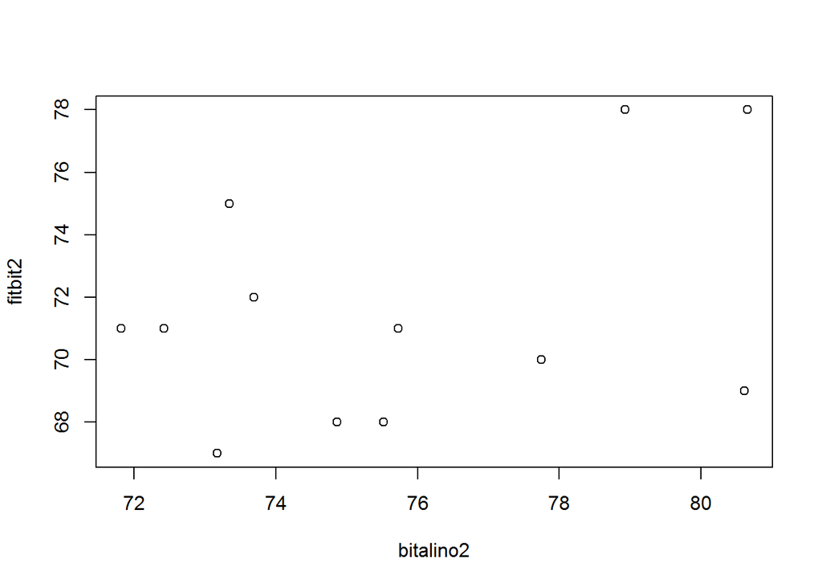

```r
plot(fitbit2 ~ bitalino2)
```